# BANA6043-Final Project

## Group Details:

- Shama Dixit
- Shreeya Idagunji
- Haritha Sajimon
- Vibhash Dhar

## 1. Exploratory Data Analysis

### DATA DESCRIPTION

Here,we have used a UK Used Car Dataset spanning from 1997 to 2020. The dataset was obtained from Kaggle(https://www.kaggle.com/adityadesai13/used-car-dataset-ford-and-mercedes ). The dataset basically contains information about different models of used audi cars in UK and provides insights about the resale value of cars. The variables in this dataset are :

- Model : This is a categorical variable including the names of all models of audi cars evaluated in the dataset.
- Year : This is a numeric variable spanning from 1997 to 2020 and includes the year of initial purchase of each car.
- Transmission :This is a categorical variable which states whether a particular car is Manual/Automatic/Semi-Auto.
- Price : This is a numerical variable which indicates the resale price of each car.
- Mileage : This is a numerical variable which indicates number of miles traveled by each car.
- FuelType : This is a categorical variable which has three levels, Diesel/Hybrid/Petrol.
- Tax: This is a numeric variable which indicates the onroad tax to be paid.
- mpg :This is a numeric variable which is the distance measured in miles that the car can travel per gallon of fuel.
- EngineSize : This is a numeric variable which is the measurement of total volume of cylinders in the engine. Bigger the engine size,more space there is for air and fuel inside it.

OBJECTIVE : We are trying to observe the influence of predictors on the resale price of cars.

Below is a summary of the dataset.

#### New Functions/Packages Used

We have used the following new functions & packages:

- Function **preProcess** to normalize the Data.
- **glmnet** package for Ridge, Lasso and Elastic Net Regression
- **caret** package for introducing custom parameters in models.

#### Load Required Packages and read the csv

```r
library(tidyverse)
library(GGally)
library(randomForest)
library(e1071)
library(caret)
library(glmnet)
library(mlbench)
library(psych)

d <- read.csv("audi.csv")
summary(d)
```

```
##     model                year          price        transmission
##  Length:10668       Min.   :1997   Min.   :  1490   Length:10668
##  Class :character   1st Qu.:2016   1st Qu.: 15131   Class :character
##  Mode  :character   Median :2017   Median : 20200   Mode  :character
##                     Mean   :2017   Mean   : 22897
##                     3rd Qu.:2019   3rd Qu.: 27990
##                     Max.   :2020   Max.   :145000
##     mileage         fuelType              tax           mpg
##  Min.   :     1   Length:10668       Min.   :  0   Min.   : 18.90
##  1st Qu.:  5969   Class :character   1st Qu.:125   1st Qu.: 40.90
##  Median : 19000   Mode  :character   Median :145   Median : 49.60
##  Mean   : 24827                      Mean   :126   Mean   : 50.77
##  3rd Qu.: 36465                      3rd Qu.:145   3rd Qu.: 58.90
##  Max.   :323000                      Max.   :580   Max.   :188.30
##    engineSize
##  Min.   :0.000
##  1st Qu.:1.500
##  Median :2.000
##  Mean   :1.931
##  3rd Qu.:2.000
##  Max.   :6.300
```

```r
str(d)
```

```
## 'data.frame':    10668 obs. of  9 variables:
##  $ model       : chr  " A1" " A6" " A1" " A4" ...
##  $ year        : int  2017 2016 2016 2017 2019 2016 2016 2016 2015 2016 ...
##  $ price       : int  12500 16500 11000 16800 17300 13900 13250 11750 10200 12000 ...
##  $ transmission: chr  "Manual" "Automatic" "Manual" "Automatic" ...
##  $ mileage     : int  15735 36203 29946 25952 1998 32260 76788 75185 46112 22451 ...
##  $ fuelType    : chr  "Petrol" "Diesel" "Petrol" "Diesel" ...
##  $ tax         : int  150 20 30 145 145 30 30 20 20 30 ...
##  $ mpg         : num  55.4 64.2 55.4 67.3 49.6 58.9 61.4 70.6 60.1 55.4 ...
##  $ engineSize  : num  1.4 2 1.4 2 1 1.4 2 2 1.4 1.4 ...
```

#### DATA CLEANING

In order to check for null values in our dataset, we have included the following. We could see that there are no null values in our dataset.

```r
sum(is.na(d$model))
```

```
## [1] 0
```

```r
sum(is.na(d$year))
```

```
## [1] 0
```

```r
sum(is.na(d$price))
```

```
## [1] 0
```

```r
sum(is.na(d$transmission))
```

```
## [1] 0
```

```r
sum(is.na(d$mileage))
```

```
## [1] 0
```

```r
sum(is.na(d$fuelType))
```

```
## [1] 0
```

```r
sum(is.na(d$tax))
```

```
## [1] 0
```

```r
sum(is.na(d$mpg))
```

```
## [1] 0
```

```r
sum(is.na(d$engineSize))
```

```
## [1] 0
```

#### VISUALIZATIONS AND DATA ANALYSIS

```r
library(sqldf)
sql1 <- sqldf('select year,avg(price) from d group by year')
sql1
```

| year | avg(price) |
| --- | --- |
| 1997 | 4650.000 |
| 1998 | 4999.000 |
| 2002 | 2433.000 |
| 2003 | 3408.333 |
| 2004 | 5053.600 |
| 2005 | 3490.714 |
| 2006 | 6499.111 |
| 2007 | 7325.250 |
| 2008 | 6281.429 |
| 2009 | 6281.957 |

[output cut: 11 more lines]

```r
sql2 <- sqldf('select model,avg(price) from d group by model order by avg(price)')
sql2
```

| model | avg(price) |
| --- | --- |
| A2 | 2490.00 |
| A1 | 14327.75 |
| S5 | 15980.00 |
| A3 | 17408.52 |
| A4 | 20255.45 |
| S3 | 20379.44 |
| TT | 21784.45 |
| Q2 | 22516.98 |
| A6 | 22695.39 |
| Q3 | 22999.26 |

[output cut: 16 more lines]

```r
sql3 <- sqldf('select transmission,avg(price) from d group by transmission')
sql3
```

| transmission | avg(price) |
| --- | --- |
| Automatic | 28204.75 |
| Manual | 16101.03 |
| Semi-Auto | 27161.78 |

```r
sql4 <- sqldf('select fuelType,avg(price) from d group by fuelType')
sql4
```

| fuelType | avg(price) |
| --- | --- |
| Diesel | 23237.52 |
| Hybrid | 30191.75 |
| Petrol | 22480.91 |

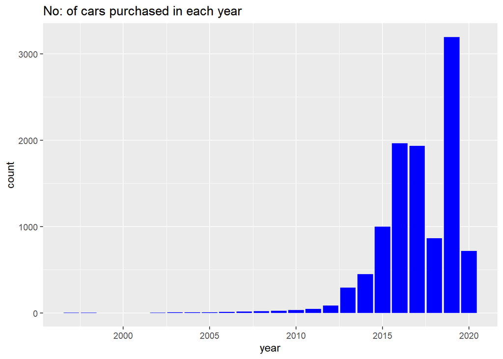

```r
ggplot(data=d)+geom_bar(mapping=aes(x=year),fill= "blue")+ggtitle("No: of cars purchased in each year")
```

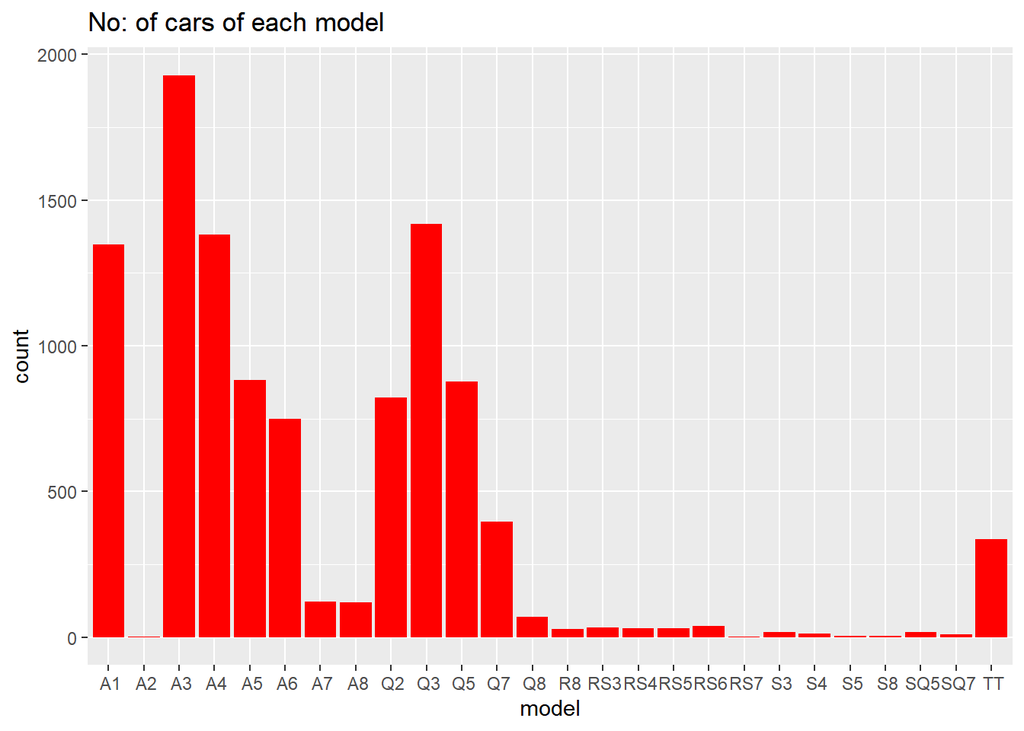

```r
ggplot(data=d)+geom_bar(mapping=aes(x=model),fill= "red")+ggtitle("No: of cars of each model")
```

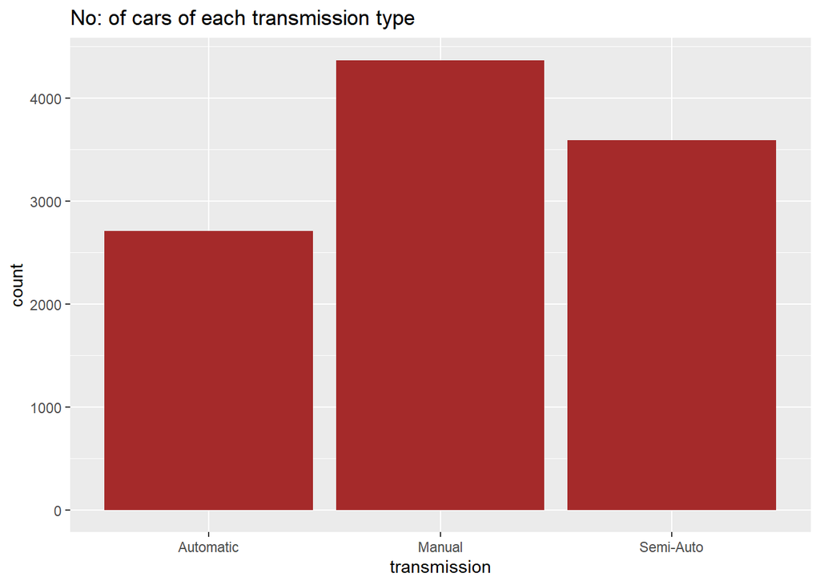

```r
ggplot(data=d)+geom_bar(mapping=aes(x=transmission),fill= "brown")+ggtitle("No: of cars of each transmission type")
```

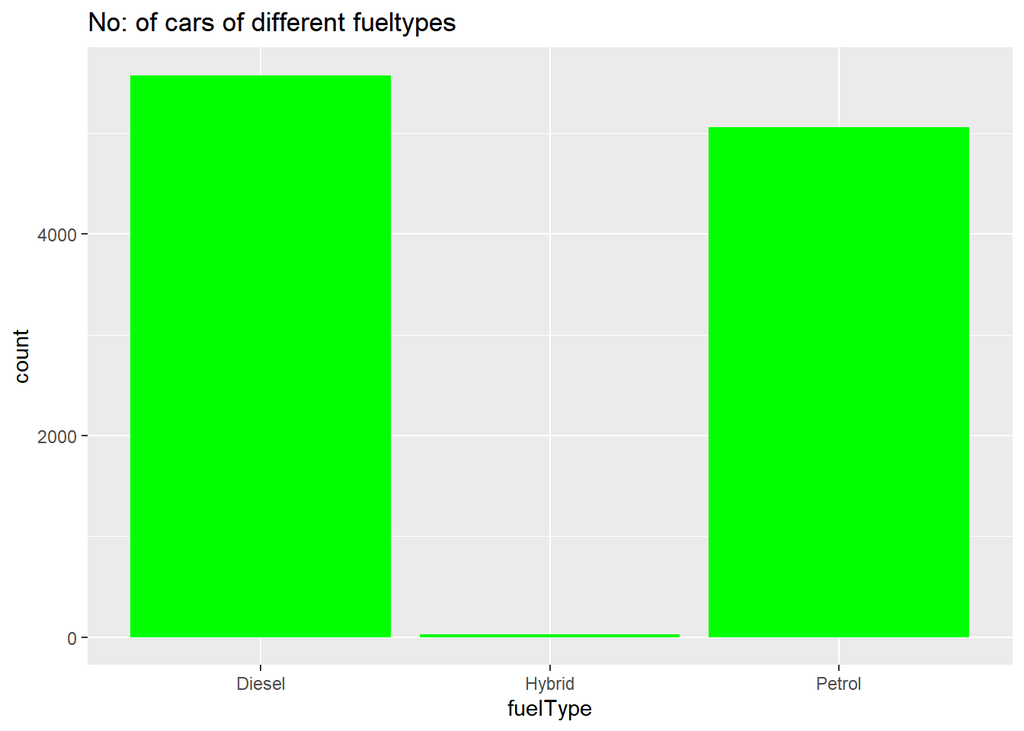

```r
ggplot(data=d)+geom_bar(mapping=aes(x=fuelType),fill= "green")+ggtitle("No: of cars of different fueltypes")
```

#### **Observations:**

- Here, we found average price of cars in each year and could observe that the average price was minimum in the year 2002 and maximum in the year 2020.
- The average price of cars was the lowest for the A2 model and highest for the R8 model.
- Automatic type cars had the highest average resale price ,whereas manual type cars had the lowest average resale price.
- Petrol cars had the lowest average resale price ,whereas hybrid model cars had the highest average resale price.

#### CORRELATION MATRIX AND SCATTER PLOTS

```r
library(tidyverse)
library(ggplot2)
library(GGally)
cor(d %>% select(year,price,mileage,tax,mpg,engineSize))
```

```
##                   year      price     mileage         tax        mpg
## year        1.00000000  0.5925815 -0.78966699  0.09306616 -0.3512809
## price       0.59258146  1.0000000 -0.53535710  0.35615699 -0.6003344
## mileage    -0.78966699 -0.5353571  1.00000000 -0.16654715  0.3951034
## tax         0.09306616  0.3561570 -0.16654715  1.00000000 -0.6359085
## mpg        -0.35128087 -0.6003344  0.39510337 -0.63590853  1.0000000
## engineSize -0.03158230  0.5912616  0.07071017  0.39307544 -0.3656207
##             engineSize
## year       -0.03158230
## price       0.59126164
## mileage     0.07071017
## tax         0.39307544
## mpg        -0.36562073
## engineSize  1.00000000
```

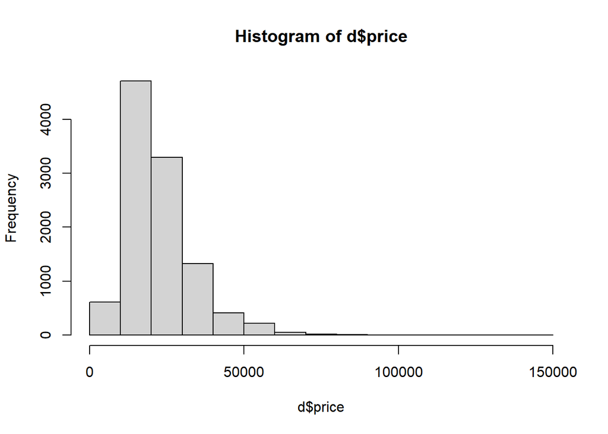

```r
hist(d$price)
```

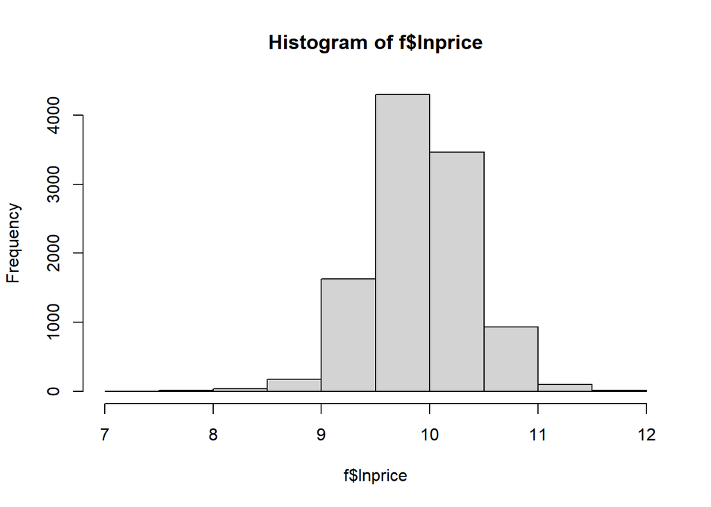

```r
f <- d %>% mutate(lnprice =log(price))
hist(f$lnprice)
```

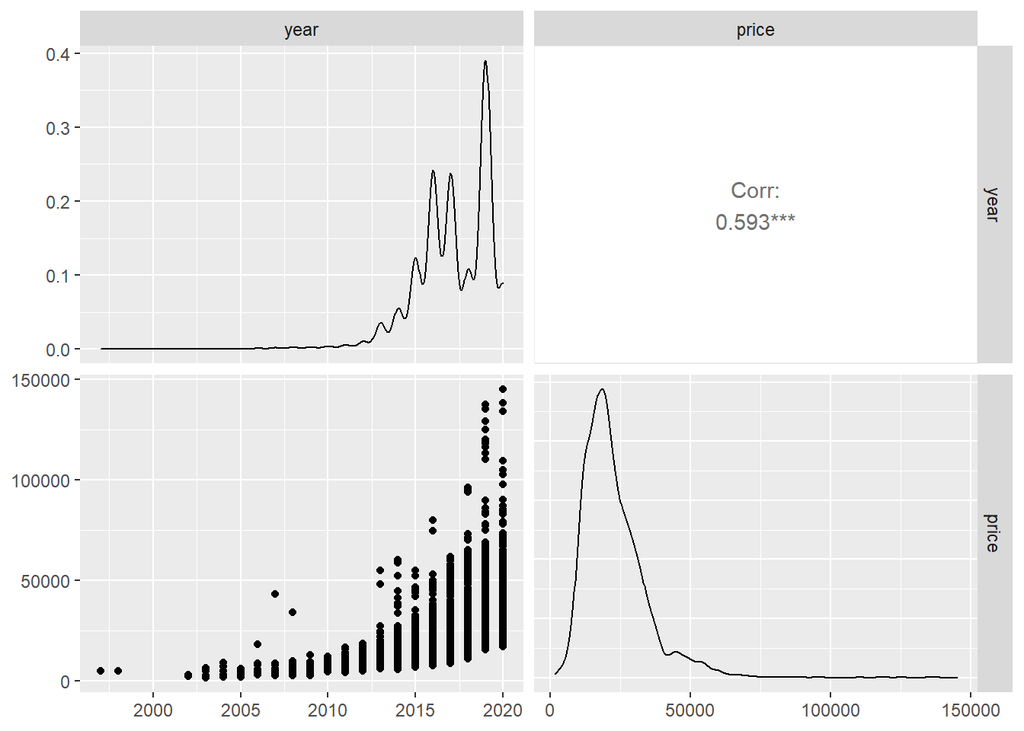

```r
ggpairs(d %>% select(year,price))
```

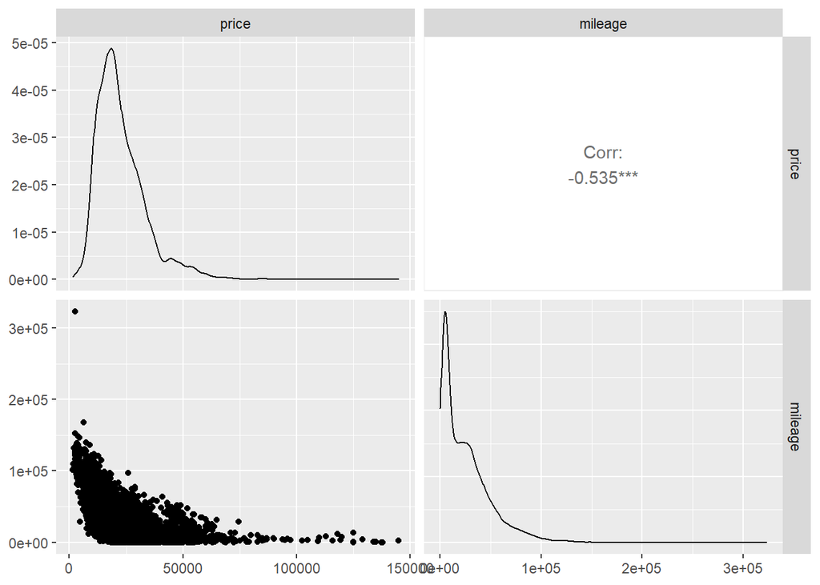

```r
ggpairs(d %>% select(price,mileage))
```

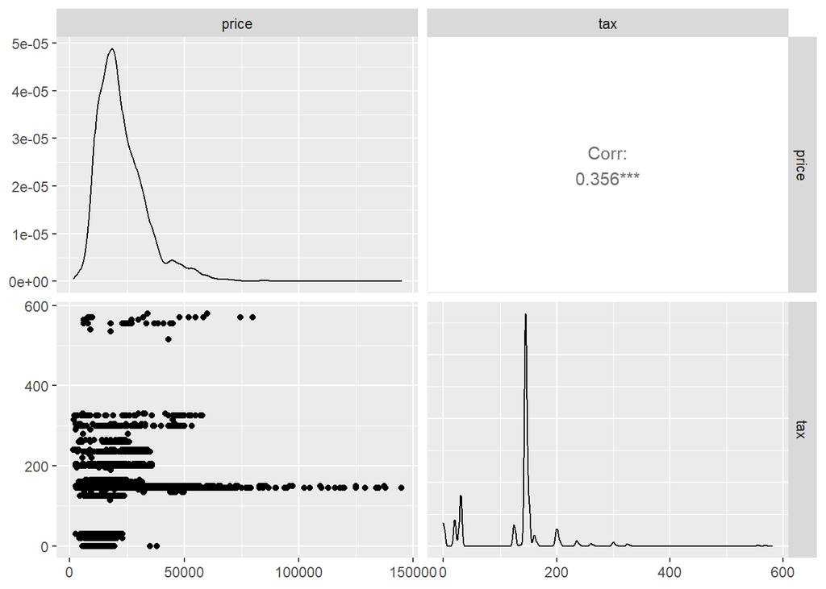

```r
ggpairs(d %>% select(price,tax))
```

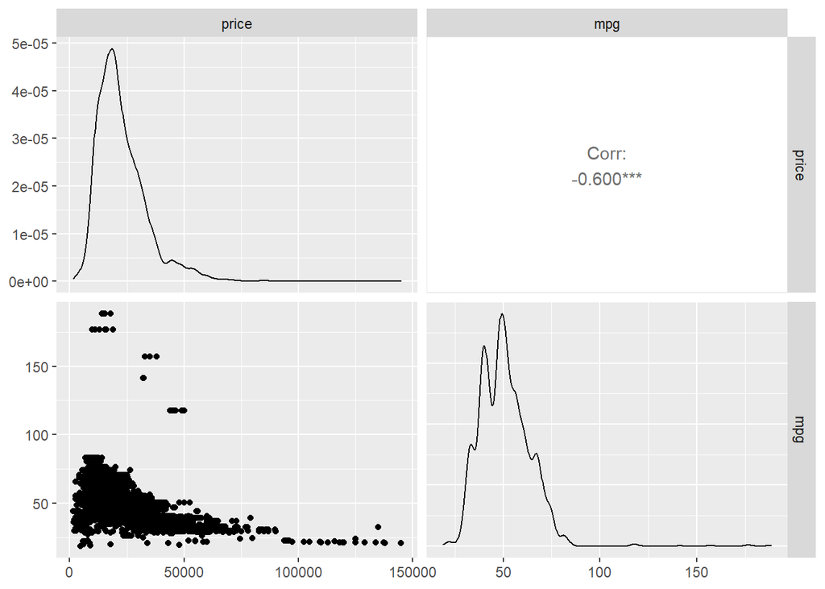

```r
ggpairs(d %>% select(price,mpg))
```

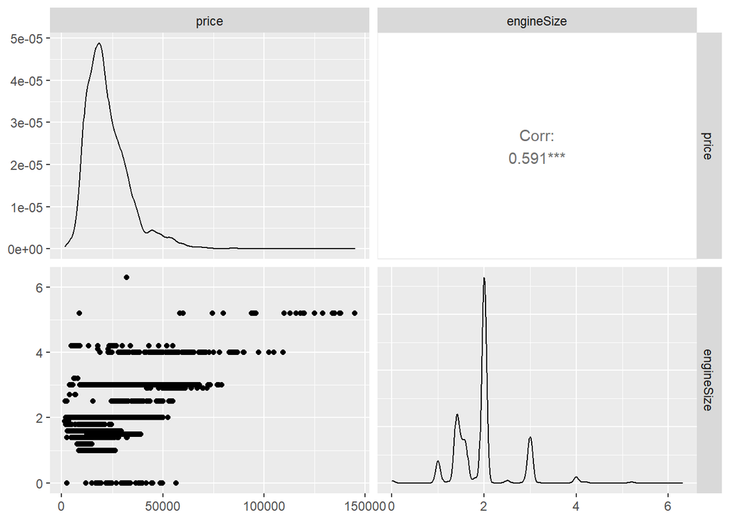

```r
ggpairs(d %>% select(price,engineSize))
```

#### **Observations:**

- The year and price variables appear to be positively correlated as shown by scatter plot and correlation coefficients.
- The price and mileage variables appear to be negatively correlated as shown by scatter plot and correlation coefficients.
- The price and tax variables appear to be positively correlated as shown by scatter plot and correlation coefficients.
- The price and mpg variables appear to be negatively correlated as shown by scatter plot and correlation coefficients.
- The price and engineSize variables appear to be positively correlated as shown by scatter plot and correlation coefficients.

#### CORRELATION MATRIX

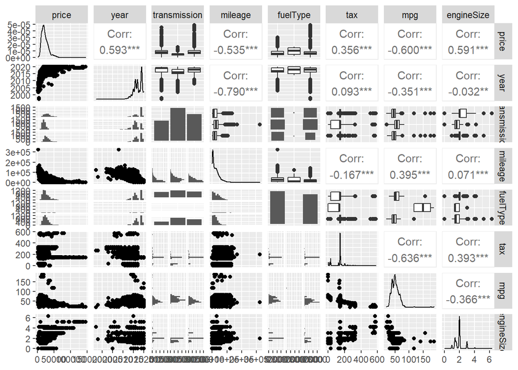

```r
data <- read.csv('audi.csv', header=TRUE)
ggpairs(data %>% select(price, year, transmission, mileage, fuelType, tax, mpg, engineSize), bins=10)
```

## 2. Splitting and Manipulating the data

```r
set.seed(123)

idx <- sample(nrow(data), .7*nrow(data))
train <- data[idx, ]
test <- data[-idx, ]
str(train)
```

```
## 'data.frame':    7467 obs. of  9 variables:
##  $ model       : chr  " A4" " Q5" " A4" " A3" ...
##  $ year        : int  2017 2016 2018 2018 2015 2018 2017 2019 2015 2017 ...
##  $ price       : int  19220 28698 20290 14500 16406 18995 19490 48000 21990 19990 ...
##  $ transmission: chr  "Manual" "Automatic" "Automatic" "Semi-Auto" ...
##  $ mileage     : int  14378 44419 19450 22496 12123 5864 13248 5900 37200 31191 ...
##  $ fuelType    : chr  "Diesel" "Diesel" "Petrol" "Diesel" ...
##  $ tax         : int  30 235 150 145 160 145 125 145 235 145 ...
##  $ mpg         : num  67.3 42.2 50.4 72.4 44.8 47.1 50.4 50.4 44.8 58.9 ...
##  $ engineSize  : num  2 3 1.4 1.6 2 1 1.4 3 3 2 ...
```

```r
str(test)
```

```
## 'data.frame':    3201 obs. of  9 variables:
##  $ model       : chr  " A1" " A4" " A1" " A4" ...
##  $ year        : int  2016 2017 2016 2016 2016 2016 2017 2015 2018 2017 ...
##  $ price       : int  11000 16800 13900 11750 12000 19000 22500 17500 15800 16000 ...
##  $ transmission: chr  "Manual" "Automatic" "Automatic" "Manual" ...
##  $ mileage     : int  29946 25952 32260 75185 22451 37652 21649 62748 10793 47482 ...
##  $ fuelType    : chr  "Petrol" "Diesel" "Petrol" "Diesel" ...
##  $ tax         : int  30 145 30 20 30 200 145 150 145 150 ...
##  $ mpg         : num  55.4 67.3 58.9 70.6 55.4 47.1 58.9 53.3 56.5 47.9 ...
##  $ engineSize  : num  1.4 2 1.4 2 1.4 2 3 3 1.4 1.4 ...
```

#### Manipulate the data and scale it using preProcess function in caret package.

```r
col_n <- c('mpg', 'mileage', 'tax', 'engineSize')

proc <- preProcess(train[,col_n], method = c('center', 'scale'))

train[,col_n] <- predict(proc, train[,col_n])
test[,col_n] <- predict(proc, test[,col_n])

summary(train)
```

```
##     model                year          price        transmission
##  Length:7467        Min.   :1998   Min.   :  1699   Length:7467
##  Class :character   1st Qu.:2016   1st Qu.: 15250   Class :character
##  Mode  :character   Median :2017   Median : 20444   Mode  :character
##                     Mean   :2017   Mean   : 22918
##                     3rd Qu.:2019   3rd Qu.: 27990
##                     Max.   :2020   Max.   :145000
##     mileage          fuelType              tax                mpg
##  Min.   :-1.0485   Length:7467        Min.   :-1.91190   Min.   :-2.50029
##  1st Qu.:-0.7992   Class :character   1st Qu.:-0.02977   1st Qu.:-0.78431
##  Median :-0.2481   Mode  :character   Median : 0.27137   Median :-0.08342
##  Mean   : 0.0000                      Mean   : 0.00000   Mean   : 0.00000
##  3rd Qu.: 0.4826                      3rd Qu.: 0.27137   3rd Qu.: 0.56913
##  Max.   :12.6149                      Max.   : 6.82118   Max.   :11.09057
##    engineSize
##  Min.   :-3.2040
##  1st Qu.:-0.7211
##  Median : 0.1066
##  Mean   : 0.0000
##  3rd Qu.: 0.1066
##  Max.   : 7.2242
```

## 3. Simple Linear Model

The simplest form of regression is linear regression, which assumes that the predictors have a linear relationship with the target variable. The input variables are assumed to have a Gaussian distribution and are not correlated with each other (a problem called multi-collinearity).

The linear regression equation can be expressed in the following form: y = a1x1 + a2x2 + a3x3 + ….. + anxn + b

In the above equation:

y is the target variable. x1, x2, x3, … xn are the features.  
a1, a2, a3, … an are the coefficients.  
b is the parameter of the model.

The parameters a and b in the model are selected through the ordinary least squares (OLS) method. This method works by minimizing the sum of squares of residuals (actual value - predicted value).

```r
linear_model <- lm(price ~ ., data = train)
summary(linear_model)
```

```
##
## Call:
## lm(formula = price ~ ., data = train)
##
## Residuals:
##    Min     1Q Median     3Q    Max
## -31030  -2113   -374   1583  43251
##
## Coefficients:
##                         Estimate Std. Error t value Pr(>|t|)
## (Intercept)           -3.637e+06  7.288e+04 -49.904  < 2e-16 ***
## model A2               1.872e+04  3.870e+03   4.837 1.34e-06 ***
## model A3               1.191e+03  1.725e+02   6.903 5.50e-12 ***
## model A4               1.569e+03  2.022e+02   7.758 9.80e-15 ***
## model A5               2.844e+03  2.296e+02  12.390  < 2e-16 ***
## model A6               3.427e+03  2.543e+02  13.479  < 2e-16 ***
## model A7               4.183e+03  4.776e+02   8.757  < 2e-16 ***
## model A8               7.851e+03  4.920e+02  15.957  < 2e-16 ***
## model Q2               1.352e+03  2.199e+02   6.146 8.34e-10 ***
## model Q3               2.781e+03  2.057e+02  13.521  < 2e-16 ***
## model Q5               6.441e+03  2.599e+02  24.778  < 2e-16 ***
## model Q7               1.497e+04  3.698e+02  40.476  < 2e-16 ***
## model Q8               2.387e+04  6.088e+02  39.212  < 2e-16 ***
## model R8               5.892e+04  1.018e+03  57.856  < 2e-16 ***
## model RS3              9.642e+03  8.517e+02  11.322  < 2e-16 ***
## model RS4              2.008e+04  8.945e+02  22.449  < 2e-16 ***
## model RS5              2.080e+04  9.205e+02  22.593  < 2e-16 ***
## model RS6              2.620e+04  7.994e+02  32.771  < 2e-16 ***
## model RS7              1.932e+04  3.883e+03   4.977 6.60e-07 ***
## model S3               3.727e+03  1.125e+03   3.313 0.000926 ***
## model S4               1.060e+04  1.388e+03   7.633 2.57e-14 ***
## model S5               2.023e+03  2.242e+03   0.903 0.366731
## model S8               3.587e+03  2.748e+03   1.305 0.191889
## model SQ5              1.123e+04  1.185e+03   9.477  < 2e-16 ***
## model SQ7              1.927e+04  1.500e+03  12.845  < 2e-16 ***
## model TT               3.394e+03  2.962e+02  11.461  < 2e-16 ***
## year                   1.813e+03  3.613e+01  50.190  < 2e-16 ***
## transmissionManual    -1.552e+03  1.341e+02 -11.570  < 2e-16 ***
## transmissionSemi-Auto  9.309e+01  1.203e+02   0.774 0.439177
## mileage               -1.816e+03  7.727e+01 -23.496  < 2e-16 ***
## fuelTypeHybrid         3.534e+04  1.268e+03  27.876  < 2e-16 ***
## fuelTypePetrol        -1.176e+03  1.415e+02  -8.308  < 2e-16 ***
## tax                   -2.019e+03  6.663e+01 -30.302  < 2e-16 ***
## mpg                   -3.826e+03  1.009e+02 -37.919  < 2e-16 ***
## engineSize             2.621e+03  8.830e+01  29.680  < 2e-16 ***
## ---
## Signif. codes:  0 '***' 0.001 '**' 0.01 '*' 0.05 '.' 0.1 ' ' 1
##
## Residual standard error: 3849 on 7432 degrees of freedom
## Multiple R-squared:  0.8914, Adjusted R-squared:  0.8909
## F-statistic:  1795 on 34 and 7432 DF,  p-value: < 2.2e-16
```

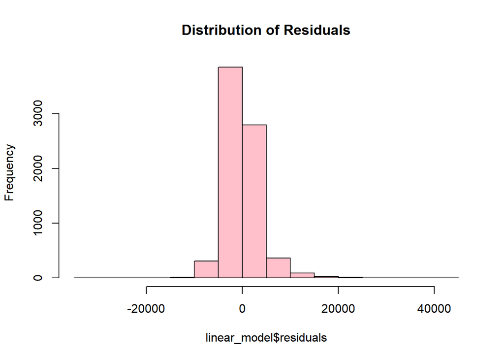

```r
hist(linear_model$residuals, main = 'Distribution of Residuals', col = 'pink')
```

#### Use the model and test data to predict the prices

```r
preds_lm <- predict(linear_model, newdata = test)
```

#### Performance of the model on the basis of RMSE, MAE and RSquared

```r
calc_performance <- function(actual, predicted) {
  rmse <- sqrt(mean((actual - predicted)**2))
  mae <- mean(abs(actual - predicted))
  rsq <- 1 - (sum((actual - predicted)**2))/(sum((actual - mean(actual))**2))
  return(c(RMSE = rmse, MAE = mae, RSquared = rsq))
}
calc_performance(train$price, linear_model$fitted.values)
```

```
##         RMSE          MAE     RSquared
## 3839.6700179 2585.0182484    0.8914284
```

```r
calc_performance(test$price, preds_lm)
```

```
##         RMSE          MAE     RSquared
## 3911.1067595 2555.8318067    0.8911766
```

RMSE and MAE values for train and test datasets are almost similar, thus we can say that model performance is reasonably good.

Now, let us evaluate other regression models to see if we can come up with a better model for price prediction.

## 4. Define Custom Control Parameters

We will use trainControl function present in caret package to define custom control parameters for regression models.

We have used the below parameters for creating a custom control:

1. method = ‘repeatedcv’; CV: Cross Validation
2. number = 10; In 10 fold cross validation, training data is split into 10 parts out of which 9 are used for model building and 1 is used for error estimation.
3. repeat = 10; CV is repeated 10 times.

```r
custom <- trainControl(method = 'repeatedcv',
                       number = 10,
                       repeats = 10)
```

## 5. Linear, Ridge, Lasso and Elastic Net Regression Models

### 5.1 Linear Regression Model using custom control parameters

```r
set.seed(123)
lm <- train(price~., train, method = 'lm', trControl = custom)

lm$results
```

|  | intercept | RMSE | Rsquared | MAE | RMSESD | RsquaredSD | MAESD |
| --- | --- | --- | --- | --- | --- | --- | --- |
| 1 | TRUE | 3905.909 | 0.8878181 | 2611.595 | 274.0985 | 0.01322403 | 98.47677 |

```r
lm
```

```
## Linear Regression
##
## 7467 samples
##    8 predictor
##
## No pre-processing
## Resampling: Cross-Validated (10 fold, repeated 10 times)
## Summary of sample sizes: 6720, 6720, 6719, 6722, 6721, 6721, ...
## Resampling results:
##
##   RMSE      Rsquared   MAE
##   3905.909  0.8878181  2611.595
##
## Tuning parameter 'intercept' was held constant at a value of TRUE
```

```r
summary(lm)
```

```
##
## Call:
## lm(formula = .outcome ~ ., data = dat)
##
## Residuals:
##    Min     1Q Median     3Q    Max
## -31030  -2113   -374   1583  43251
##
## Coefficients:
##                           Estimate Std. Error t value Pr(>|t|)
## (Intercept)             -3.637e+06  7.288e+04 -49.904  < 2e-16 ***
## `model A2`               1.872e+04  3.870e+03   4.837 1.34e-06 ***
## `model A3`               1.191e+03  1.725e+02   6.903 5.50e-12 ***
## `model A4`               1.569e+03  2.022e+02   7.758 9.80e-15 ***
## `model A5`               2.844e+03  2.296e+02  12.390  < 2e-16 ***
## `model A6`               3.427e+03  2.543e+02  13.479  < 2e-16 ***
## `model A7`               4.183e+03  4.776e+02   8.757  < 2e-16 ***
## `model A8`               7.851e+03  4.920e+02  15.957  < 2e-16 ***
## `model Q2`               1.352e+03  2.199e+02   6.146 8.34e-10 ***
## `model Q3`               2.781e+03  2.057e+02  13.521  < 2e-16 ***
## `model Q5`               6.441e+03  2.599e+02  24.778  < 2e-16 ***
## `model Q7`               1.497e+04  3.698e+02  40.476  < 2e-16 ***
## `model Q8`               2.387e+04  6.088e+02  39.212  < 2e-16 ***
## `model R8`               5.892e+04  1.018e+03  57.856  < 2e-16 ***
## `model RS3`              9.642e+03  8.517e+02  11.322  < 2e-16 ***
## `model RS4`              2.008e+04  8.945e+02  22.449  < 2e-16 ***
## `model RS5`              2.080e+04  9.205e+02  22.593  < 2e-16 ***
## `model RS6`              2.620e+04  7.994e+02  32.771  < 2e-16 ***
## `model RS7`              1.932e+04  3.883e+03   4.977 6.60e-07 ***
## `model S3`               3.727e+03  1.125e+03   3.313 0.000926 ***
## `model S4`               1.060e+04  1.388e+03   7.633 2.57e-14 ***
## `model S5`               2.023e+03  2.242e+03   0.903 0.366731
## `model S8`               3.587e+03  2.748e+03   1.305 0.191889
## `model SQ5`              1.123e+04  1.185e+03   9.477  < 2e-16 ***
## `model SQ7`              1.927e+04  1.500e+03  12.845  < 2e-16 ***
## `model TT`               3.394e+03  2.962e+02  11.461  < 2e-16 ***
## year                     1.813e+03  3.613e+01  50.190  < 2e-16 ***
## transmissionManual      -1.552e+03  1.341e+02 -11.570  < 2e-16 ***
## `transmissionSemi-Auto`  9.309e+01  1.203e+02   0.774 0.439177
## mileage                 -1.816e+03  7.727e+01 -23.496  < 2e-16 ***
## fuelTypeHybrid           3.534e+04  1.268e+03  27.876  < 2e-16 ***
## fuelTypePetrol          -1.176e+03  1.415e+02  -8.308  < 2e-16 ***
## tax                     -2.019e+03  6.663e+01 -30.302  < 2e-16 ***
## mpg                     -3.826e+03  1.009e+02 -37.919  < 2e-16 ***
## engineSize               2.621e+03  8.830e+01  29.680  < 2e-16 ***
## ---
## Signif. codes:  0 '***' 0.001 '**' 0.01 '*' 0.05 '.' 0.1 ' ' 1
##
## Residual standard error: 3849 on 7432 degrees of freedom
## Multiple R-squared:  0.8914, Adjusted R-squared:  0.8909
## F-statistic:  1795 on 34 and 7432 DF,  p-value: < 2.2e-16
```

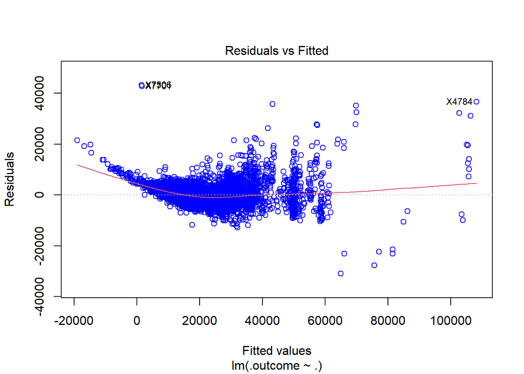

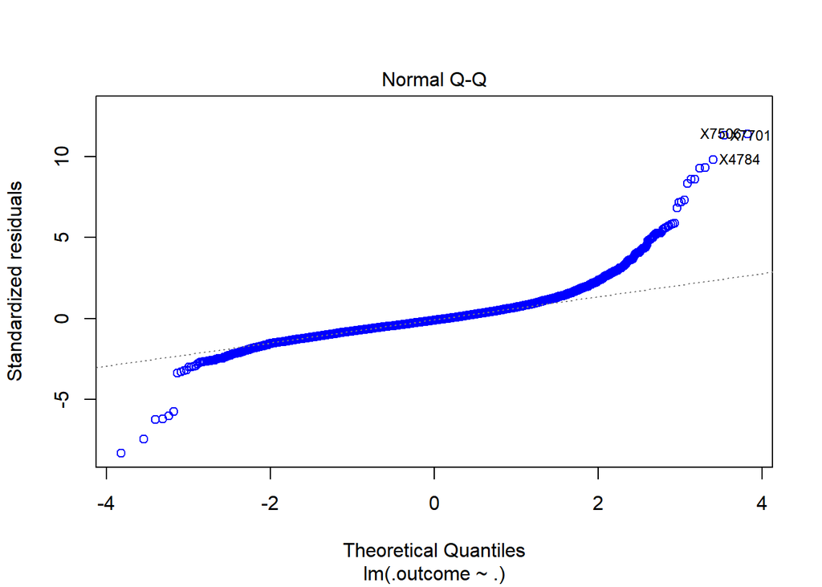

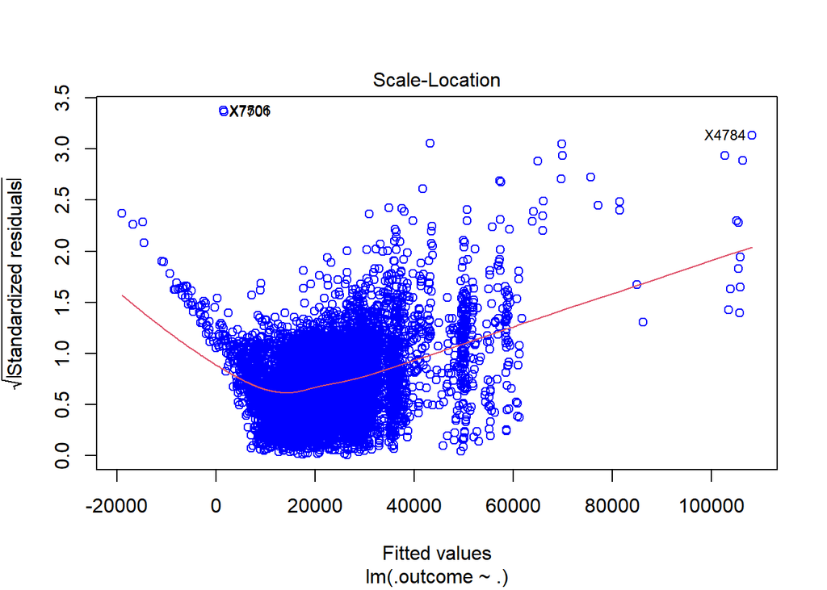

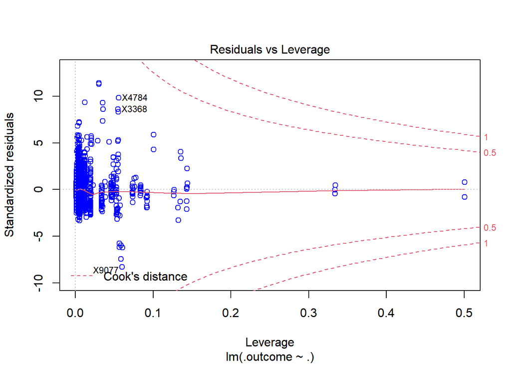

```r
plot(lm$finalModel, col = 'blue')
```

### 5.2 Ridge Regression Model

Ridge regression is an extension of linear regression where the loss function is modified to minimize the complexity of the model. This modification is done by adding a penalty parameter that is equivalent to the square of the magnitude of the coefficients.

**Loss function = OLS + alpha * summation (squared coefficient values)**

Ridge Regression tries to shrink the coefficients by trying to shrink the coefficients, but keeps all the variables in the model.

Ridge regression is also referred to as l2 regularization. The arguments used in the model are:

**alpha**: determines the weighting to be used. In case of ridge regression, the value of alpha is zero.

**family**: determines the distribution family to be used. Since this is a regression model, we will use the Gaussian distribution.

**lambda**: determines the lambda values to be tried. lambda is the strength of the penalty on the coefficients.

```r
set.seed(123)
ridge <- train(price ~ ., train, method = 'glmnet',
               tuneGrid = expand.grid(alpha=0,
                                      lambda= seq(100, 1000, length=10)),
                                      trControl = custom)
ridge
```

```
## glmnet
##
## 7467 samples
##    8 predictor
##
## No pre-processing
## Resampling: Cross-Validated (10 fold, repeated 10 times)
## Summary of sample sizes: 6720, 6720, 6719, 6722, 6721, 6721, ...
## Resampling results across tuning parameters:
##
##   lambda  RMSE      Rsquared   MAE
##    100    3958.446  0.8857677  2593.807
##    200    3958.446  0.8857677  2593.807
##    300    3958.446  0.8857677  2593.807
##    400    3958.446  0.8857677  2593.807
##    500    3958.446  0.8857677  2593.807
##    600    3958.446  0.8857677  2593.807
##    700    3958.446  0.8857677  2593.807
##    800    3966.885  0.8854646  2595.013
##    900    3978.744  0.8850409  2597.049
##   1000    3991.050  0.8846090  2599.526
##
## Tuning parameter 'alpha' was held constant at a value of 0
## RMSE was used to select the optimal model using the smallest value.
## The final values used for the model were alpha = 0 and lambda = 700.
```

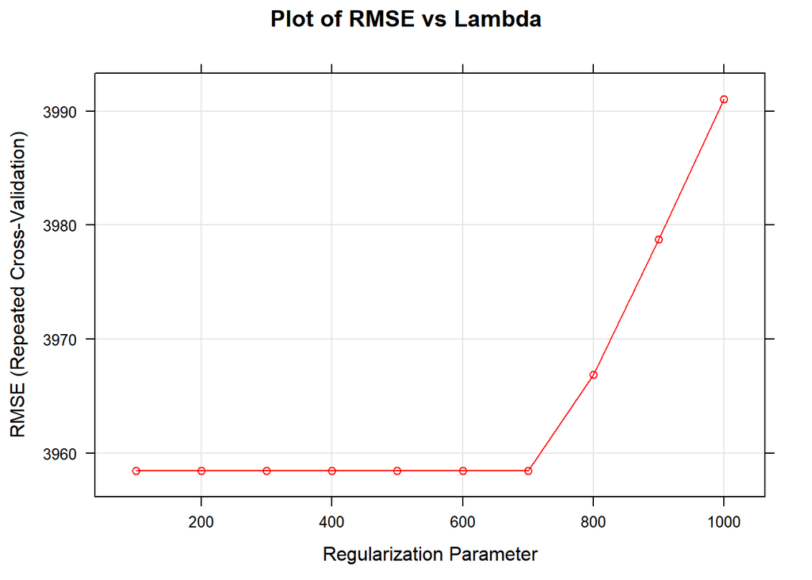

```r
plot(ridge, col = 'red', main='Plot of RMSE vs Lambda')
```

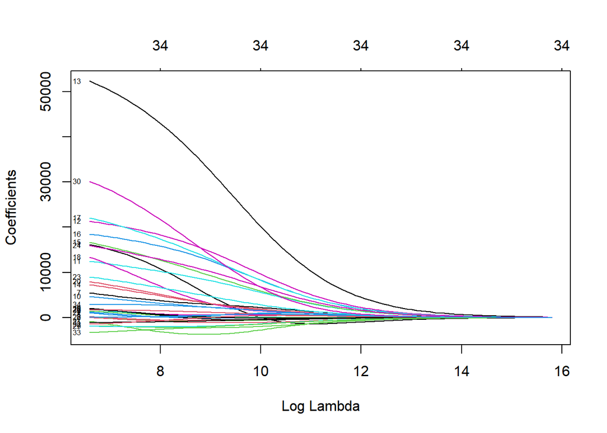

```r
plot(ridge$finalModel, xvar='lambda', label=TRUE)
```

##### **Observations:**

- We can see that RMSE is constant till lambda value of 700, after which is starts to increase. So, the model has selected lambda value of 700.
- We can see from plot of coefficients vs Log Lambda that as Lambda tends to 15, all coefficients become more or less equal to 0.
- The plot shows that at all times all 34 variables are present in the model(see top part of Coefficients vs Log Lambda plot).

### 5.3 LASSO Regression

Lasso regression, or the Least Absolute Shrinkage and Selection Operator, is also a modification of linear regression. In lasso, the loss function is modified to minimize the complexity of the model by limiting the sum of the absolute values of the model coefficients.

Alpha value for LASSO is 1.

```r
set.seed(123)
lasso <- train(price ~ ., train,
               method = 'glmnet',
               tuneGrid = expand.grid(alpha=1,
                                      lambda= seq(1, 5, length=20)),
                                      trControl = custom)

lasso
```

```
## glmnet
##
## 7467 samples
##    8 predictor
##
## No pre-processing
## Resampling: Cross-Validated (10 fold, repeated 10 times)
## Summary of sample sizes: 6720, 6720, 6719, 6722, 6721, 6721, ...
## Resampling results across tuning parameters:
##
##   lambda    RMSE      Rsquared   MAE
##   1.000000  3906.553  0.8877758  2611.197
##   1.210526  3906.553  0.8877758  2611.197
##   1.421053  3906.553  0.8877758  2611.197
##   1.631579  3906.553  0.8877758  2611.197
##   1.842105  3906.553  0.8877758  2611.197
##   2.052632  3906.553  0.8877758  2611.197
##   2.263158  3906.553  0.8877758  2611.197
##   2.473684  3906.553  0.8877758  2611.197
##   2.684211  3906.553  0.8877758  2611.197
##   2.894737  3906.553  0.8877758  2611.197
##   3.105263  3906.553  0.8877758  2611.197
##   3.315789  3906.553  0.8877758  2611.197
##   3.526316  3906.553  0.8877758  2611.197
##   3.736842  3906.553  0.8877758  2611.197
##   3.947368  3906.553  0.8877758  2611.197
##   4.157895  3906.553  0.8877758  2611.197
##   4.368421  3906.553  0.8877758  2611.197
##   4.578947  3906.553  0.8877758  2611.197
##   4.789474  3906.583  0.8877742  2611.202
##   5.000000  3906.643  0.8877707  2611.212
##
## Tuning parameter 'alpha' was held constant at a value of 1
## RMSE was used to select the optimal model using the smallest value.
## The final values used for the model were alpha = 1 and lambda = 4.578947.
```

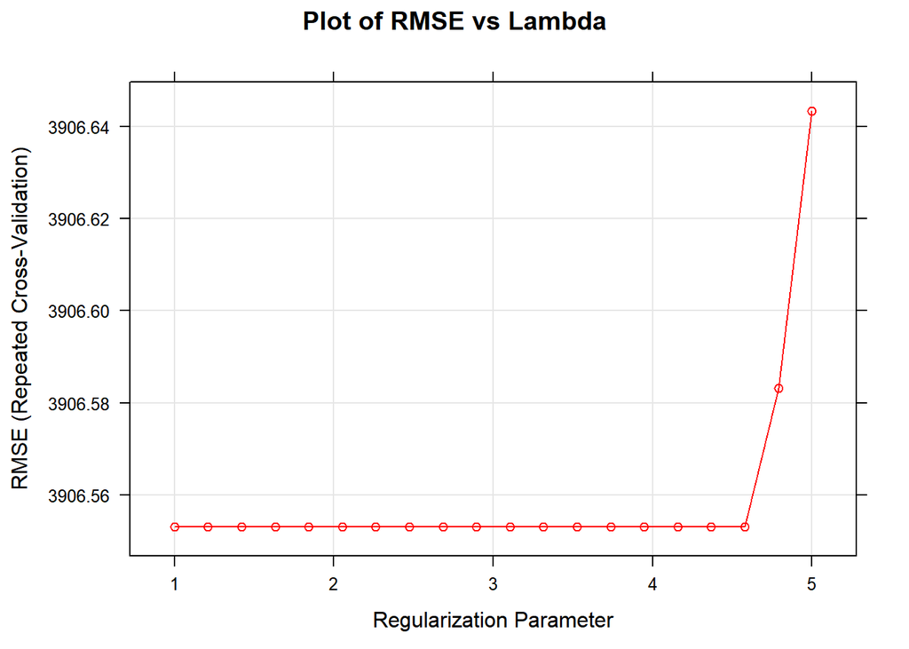

```r
plot(lasso, col = 'red', main='Plot of RMSE vs Lambda')
```

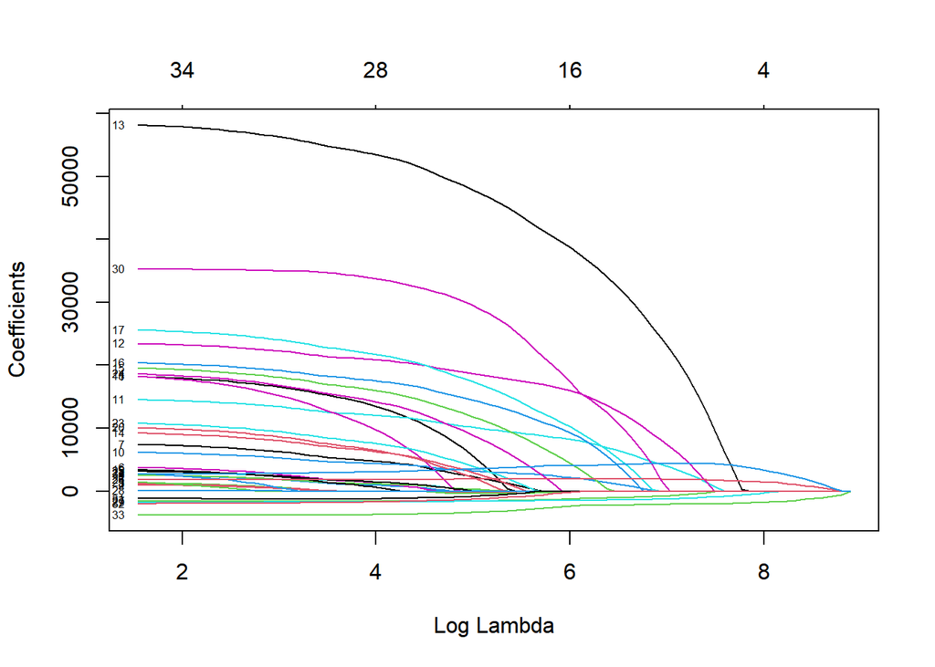

```r
plot(lasso$finalModel, xvar='lambda', label=TRUE)
```

##### **Observations:**

- We can see that RMSE is constant till lambda value of approximately 4.6, after which is starts to increase. So, the model has selected lambda value of 4.6.
- We can see from plot of coefficients vs Log Lambda that as Log Lambda tends to ~9, all coefficients become more or less equal to 0.
- The plot shows that LASSO deflates the number of variables and as Log Lambda tends to > 8 only 4 Variables are left in the model.

### 5.4. Elastic Net Regression

Elastic net regression combines the properties of ridge and lasso regression. It works by penalizing the model using both the 1l2-norm1 and the 1l1-norm1. The model can be easily built using the caret package.

```r
set.seed(123)
en <- train(price ~ ., train,
               method = 'glmnet',
               tuneGrid = expand.grid(alpha=seq(0, 1, length=10),
                                      lambda= seq(0, 30, length=15)),
                                      trControl = custom)
en
```

```
## glmnet
##
## 7467 samples
##    8 predictor
##
## No pre-processing
## Resampling: Cross-Validated (10 fold, repeated 10 times)
## Summary of sample sizes: 6720, 6720, 6719, 6722, 6721, 6721, ...
## Resampling results across tuning parameters:
##
##   alpha      lambda     RMSE      Rsquared   MAE
##   0.0000000   0.000000  3958.446  0.8857677  2593.807
##   0.0000000   2.142857  3958.446  0.8857677  2593.807
##   0.0000000   4.285714  3958.446  0.8857677  2593.807
##   0.0000000   6.428571  3958.446  0.8857677  2593.807
##   0.0000000   8.571429  3958.446  0.8857677  2593.807
##   0.0000000  10.714286  3958.446  0.8857677  2593.807
##   0.0000000  12.857143  3958.446  0.8857677  2593.807
##   0.0000000  15.000000  3958.446  0.8857677  2593.807
##   0.0000000  17.142857  3958.446  0.8857677  2593.807
##   0.0000000  19.285714  3958.446  0.8857677  2593.807
##   0.0000000  21.428571  3958.446  0.8857677  2593.807
##   0.0000000  23.571429  3958.446  0.8857677  2593.807
##   0.0000000  25.714286  3958.446  0.8857677  2593.807
##   0.0000000  27.857143  3958.446  0.8857677  2593.807
##   0.0000000  30.000000  3958.446  0.8857677  2593.807
##   0.1111111   0.000000  3906.369  0.8877883  2609.181
##   0.1111111   2.142857  3906.369  0.8877883  2609.181
##   0.1111111   4.285714  3906.369  0.8877883  2609.181
##   0.1111111   6.428571  3906.369  0.8877883  2609.181
##   0.1111111   8.571429  3906.369  0.8877883  2609.181
##   0.1111111  10.714286  3906.369  0.8877883  2609.181
##   0.1111111  12.857143  3906.369  0.8877883  2609.181
##   0.1111111  15.000000  3906.369  0.8877883  2609.181
##   0.1111111  17.142857  3906.369  0.8877883  2609.181
##   0.1111111  19.285714  3906.369  0.8877883  2609.181
##   0.1111111  21.428571  3906.369  0.8877883  2609.181
##   0.1111111  23.571429  3906.369  0.8877883  2609.181
##   0.1111111  25.714286  3906.369  0.8877883  2609.181
##   0.1111111  27.857143  3906.437  0.8877850  2609.082
```

[output cut: 110 more lines]

```
##   1.0000000   8.571429  3907.849  0.8876992  2611.625
##   1.0000000  10.714286  3908.795  0.8876454  2612.076
##   1.0000000  12.857143  3909.976  0.8875787  2612.812
##   1.0000000  15.000000  3911.292  0.8875049  2613.660
##   1.0000000  17.142857  3912.871  0.8874165  2614.797
##   1.0000000  19.285714  3914.567  0.8873218  2615.990
##   1.0000000  21.428571  3916.553  0.8872107  2617.476
##   1.0000000  23.571429  3918.695  0.8870912  2619.064
##   1.0000000  25.714286  3920.995  0.8869630  2620.773
##   1.0000000  27.857143  3923.547  0.8868205  2622.721
##   1.0000000  30.000000  3926.121  0.8866776  2624.605
##
## RMSE was used to select the optimal model using the smallest value.
## The final values used for the model were alpha = 0.1111111 and lambda
##  = 25.71429.
```

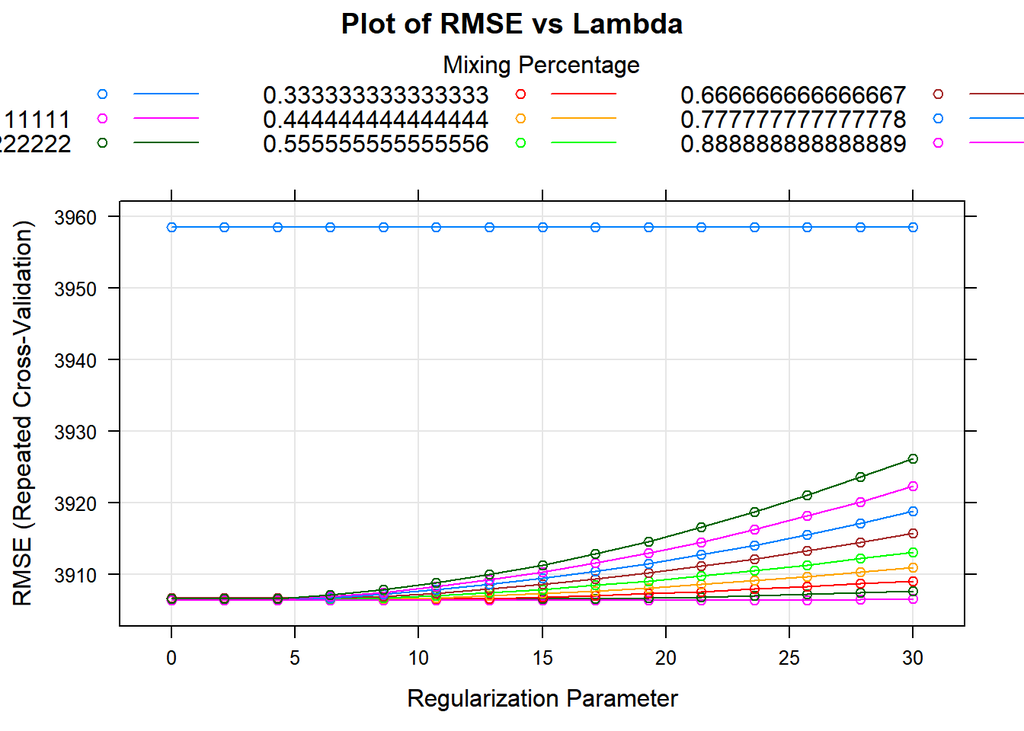

```r
plot(en, main='Plot of RMSE vs Lambda')
```

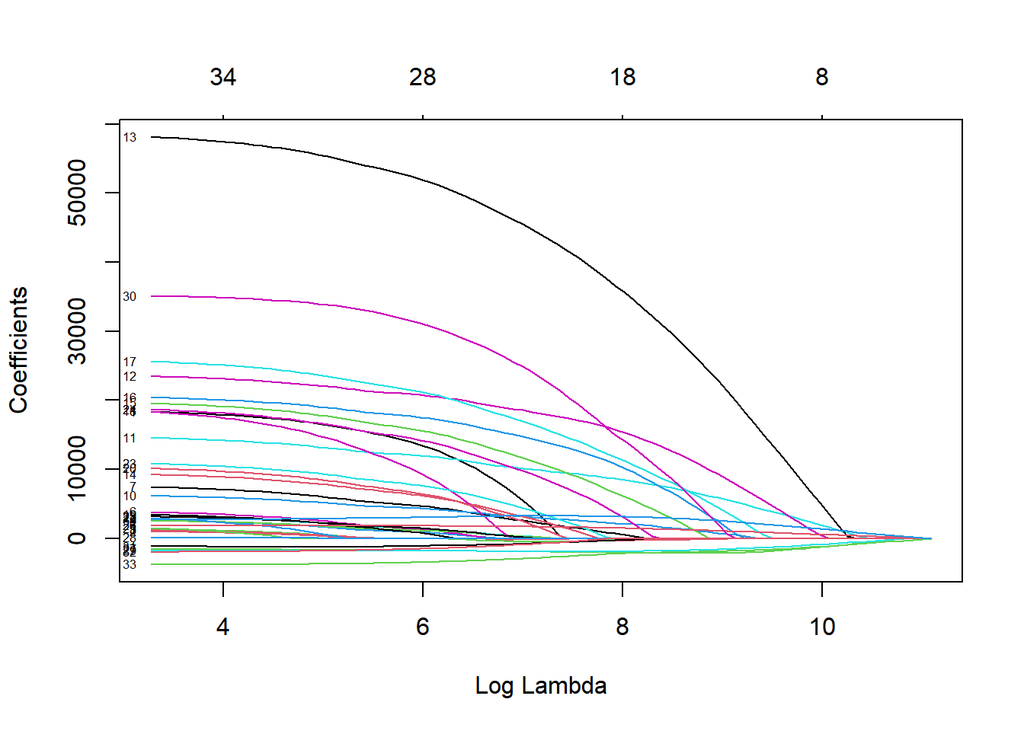

```r
plot(en$finalModel, xvar='lambda', label=TRUE)
```

##### **Observations:**

- The model chooses alpha value of 0.1111 and lambda value of 25.7143.
- Plot of RMSE vs Lambda shows mixing percentages and we can see the chosen combination of alpha = 0.1111 and lambda = 25.7143 denoted by the lowest line in the plot.
- In the plot of Log Lambda vs Coefficients, we can see that when Log Lambda tends to 10, almost all coefficients become 0 and we are left with only 8 variables in the model.

## 6. Comparing the Models

```r
model_list <- list(LinearModel = lm, Ridge = ridge, Lasso = lasso, ElasticNet = en)
res <- resamples(model_list)
summary(res)
```

```
##
## Call:
## summary.resamples(object = res)
##
## Models: LinearModel, Ridge, Lasso, ElasticNet
## Number of resamples: 100
##
## MAE
##                 Min.  1st Qu.   Median     Mean  3rd Qu.     Max. NA's
## LinearModel 2401.349 2535.527 2605.472 2611.595 2688.755 2829.182    0
## Ridge       2372.852 2517.085 2592.243 2593.807 2665.269 2841.000    0
## Lasso       2398.401 2535.907 2607.549 2611.197 2688.373 2829.141    0
## ElasticNet  2396.198 2534.204 2605.271 2609.181 2686.239 2828.018    0
##
## RMSE
##                 Min.  1st Qu.   Median     Mean  3rd Qu.     Max. NA's
## LinearModel 3354.205 3700.633 3885.622 3905.909 4111.086 4513.847    0
## Ridge       3360.412 3743.012 3952.036 3958.446 4136.938 4655.454    0
## Lasso       3355.427 3703.953 3885.217 3906.553 4117.427 4523.074    0
## ElasticNet  3355.291 3703.884 3884.819 3906.369 4114.565 4523.499    0
##
## Rsquared
##                  Min.   1st Qu.    Median      Mean   3rd Qu.      Max. NA's
## LinearModel 0.8528873 0.8791615 0.8886971 0.8878181 0.8963552 0.9178238    0
## Ridge       0.8528221 0.8769151 0.8858753 0.8857677 0.8946752 0.9143723    0
## Lasso       0.8526683 0.8792741 0.8885776 0.8877758 0.8963844 0.9176914    0
## ElasticNet  0.8528124 0.8793161 0.8885599 0.8877883 0.8963336 0.9176701    0
```

##### **Linear Model performs better than the Ridge, LASSO and Elastic Net for this dataset. Linear Model has high mean RSquared value and lowest mean RMSE**

### Predict Prices using the models

```r
pred_MLinear <- predict(lm, newdata = test)
pred_Ridge <- predict(ridge, newdata = test)
pred_Lasso <- predict(lasso, newdata = test)
pred_EN <- predict(en, newdata = test)

#include SImple Linear Model also for comparison
calc_performance(test$price, preds_lm)
```

```
##         RMSE          MAE     RSquared
## 3911.1067595 2555.8318067    0.8911766
```

```r
calc_performance(test$price, pred_MLinear)
```

```
##         RMSE          MAE     RSquared
## 3911.1067595 2555.8318067    0.8911766
```

```r
calc_performance(test$price, pred_Ridge)
```

```
##         RMSE          MAE     RSquared
## 3971.8241726 2533.1619680    0.8877715
```

```r
calc_performance(test$price, pred_Lasso)
```

```
##         RMSE          MAE     RSquared
## 3913.6639449 2553.7590163    0.8910342
```

```r
calc_performance(test$price, pred_EN)
```

```
##         RMSE          MAE     RSquared
## 3912.9786177 2551.9803794    0.8910724
```

## 7. Conclusion

In the project, we have explored linear regression models like Ridge, LASSO and Elastic Net. We also learned about the regularization techniques to get around the Multi-collinearity issue We explored custom parameters such as Cross Validation.

The performance of the Models is summarized below:

- **Simple Linear Model**: RMSE was 3911.10 and RSquared of 0.8911
- **Linear Regression using CUstom Control**: RMSE was 3911.10 and RSquared of 0.8911
- **Ridge Regression Model**: RMSE was 3971.82 and RSquared of 0.8877
- **LASSO Regression Model**: RMSE was 3913.66 and RSquared of 0.8910
- **Elastic Net Regression Model**: RMSE was 3912.97 and RSquared of 0.8910